# Room Occupancy Detection

Charles Stuppard, Mergen Narangerel

12/4/2021

#### **Introduction**

In general, occupancy sensors use a collection of sensory information to detect the presence of a person. Such sensors operate on different measurements such as: light illumination, temperature and energy (electricity) output. Industrial applications of such sensors range from home security, energy savings and automation.

Our research uses recorded data of light illumination, humidity, CO2 and temperature to detect human occupancy through the use of supervised classification models. The data has been trained and tested using “Extreme Gradient Boosting” often referred as “xgboost”. The model optimizes loss functions by using gradient descent which moves in the direction of steepest (thus most efficient) descent which minimizes the error of ground truth vs prediction (Chong, Zak p131).

From the given dataset `xgboost` was able to produce high performing results.

#### **Objective**

The objective of our model is to be able to accurately detect the presence of a person given updated information from the sensors on the test data.

$$F_i(x) = F_{i-1}(x)+f_i(x)$$

xgBoost creates new learners that predict residual errors of its parent model sequentially to improve the overall performance of the model. Weak learners that have good performance have higher vote or weight in deciding the final ensemble model.

The loss function is Gradient Descent which tries to find the direction of steepest descent of that reduces error term of the model. Unlike a neural network the weights are updated on the next predictor thereby learning from its mistake.

$w$ is weight and $n$ being our learning rate and loss being $L$.
$$w = w - n \delta w$$

$$\delta w = dL/dw$$

#### **Data**

The original dataset was obtained from the UCI Machine Learning Repository with 7 features and no missing variables.

```
##   Occupancy     n
## 1         0 15810
## 2         1  4750
```

```
##               Temperature    Humidity       Light       CO2 HumidityRatio
## Temperature     1.0000000 -0.15696350  0.68857106 0.4499887     0.2052796
## Humidity       -0.1569635  1.00000000 -0.02945884 0.2997463     0.9327237
## Light           0.6885711 -0.02945884  1.00000000 0.4481052     0.2233286
## CO2             0.4499887  0.29974628  0.44810517 1.0000000     0.4779647
## HumidityRatio   0.2052796  0.93272370  0.22332863 0.4779647     1.0000000
```

Data summary

| Name | occupancy |
| --- | --- |
| Number of rows | 20560 |
| Number of columns | 7 |
| _______________________ |  |
| Column type frequency: |  |
| character | 1 |
| factor | 1 |
| numeric | 5 |
| ________________________ |  |
| Group variables | None |

**Variable type: character**

| skim_variable | n_missing | complete_rate | min | max | empty | n_unique | whitespace |
| --- | --- | --- | --- | --- | --- | --- | --- |
| date | 0 | 1 | 19 | 19 | 0 | 20560 | 0 |

**Variable type: factor**

| skim_variable | n_missing | complete_rate | ordered | n_unique | top_counts |
| --- | --- | --- | --- | --- | --- |
| Occupancy | 0 | 1 | FALSE | 2 | 0: 15810, 1: 4750 |

**Variable type: numeric**

| skim_variable | n_missing | complete_rate | mean | sd | p0 | p25 | p50 | p75 | p100 | hist |
| --- | --- | --- | --- | --- | --- | --- | --- | --- | --- | --- |
| Temperature | 0 | 1 | 20.91 | 1.06 | 19.00 | 20.2 | 20.70 | 21.52 | 24.41 | ▃▇▃▂▁ |
| Humidity | 0 | 1 | 27.66 | 4.98 | 16.75 | 24.5 | 27.29 | 31.29 | 39.50 | ▃▆▇▆▂ |
| Light | 0 | 1 | 130.76 | 210.43 | 0.00 | 0.0 | 0.00 | 301.00 | 1697.25 | ▇▂▁▁▁ |
| CO2 | 0 | 1 | 690.55 | 311.20 | 412.75 | 460.0 | 565.42 | 804.67 | 2076.50 | ▇▂▁▁▁ |
| HumidityRatio | 0 | 1 | 0.00 | 0.00 | 0.00 | 0.0 | 0.00 | 0.00 | 0.01 | ▃▆▇▃▁ |

We do note high association between our independent variables. Such as the association between `Humidity` and `HumidityRatio`. However, Gradient Boosted Trees are known to be robust to multicollinearity. Moreover, our model conclusions will indicate stable output irrespective of the association.

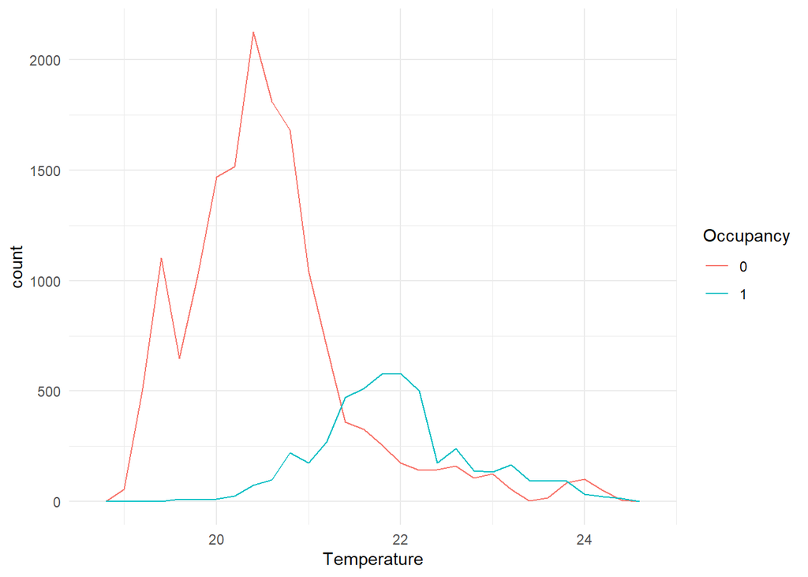

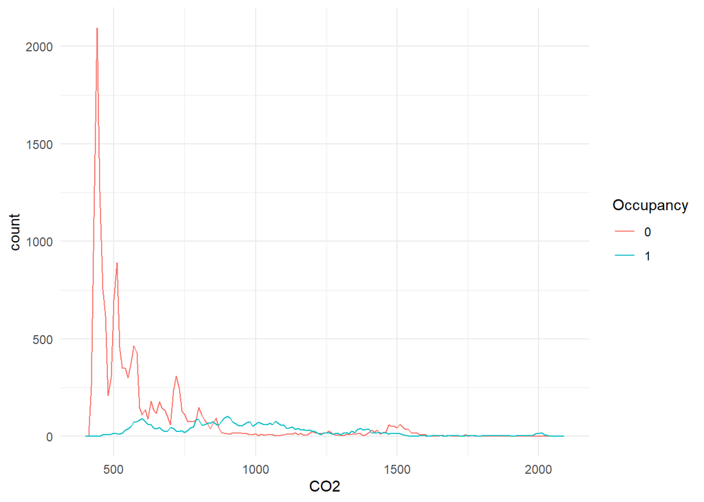

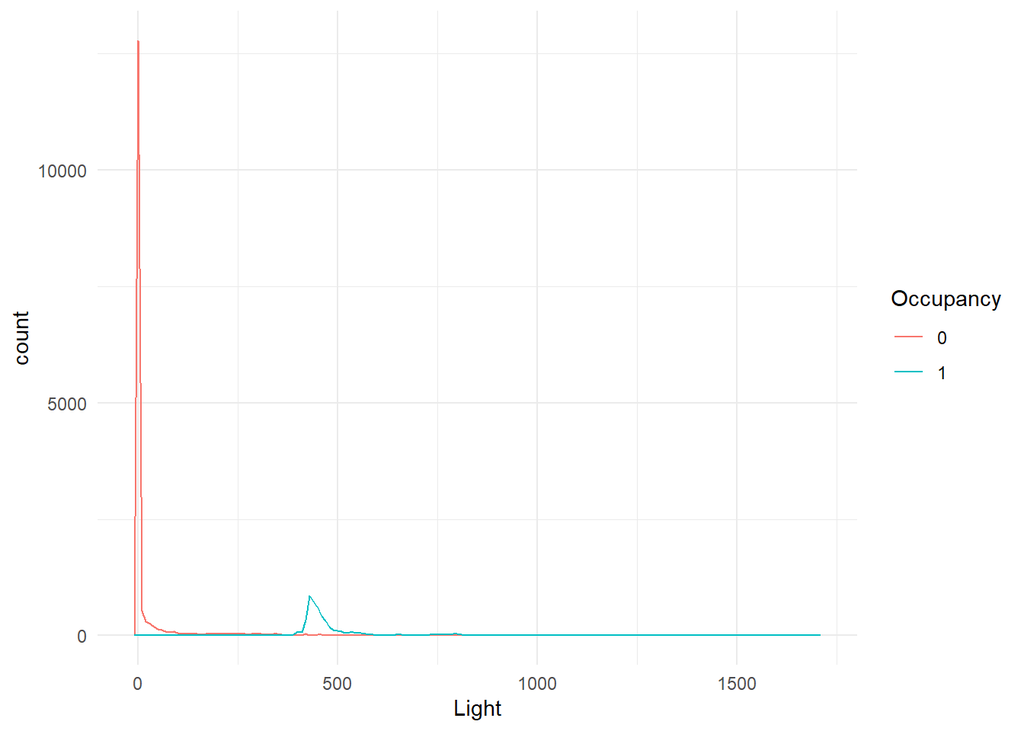

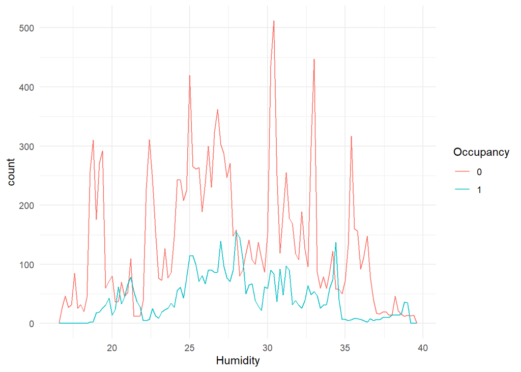

Based on the initial plots we do see that `Light` or illumination has a clear separation between occupancy states `[0,1]`. And thus it will be a strong predictor. `CO2` and `Temperature` seem to have some distinctions between occupancy states while `Humidity` has no distinction.

#### **Methods**

Our baseline approach was a binary logistic regression. However it did not pass the Box-Tidwell test. Thus not satisfying the linearity of logodds  
assumption.

```
##
## Call:
## glm(formula = Occupancy ~ Temperature + Humidity + Light + CO2 +
##     Temperature:log_temp + Humidity:log_humid + Light:log_light +
##     CO2:log_co2, family = binomial(link = "logit"), data = occ_log)
##
## Deviance Residuals:
##     Min       1Q   Median       3Q      Max
## -3.3279  -0.0005  -0.0002  -0.0001   5.0292
##
## Coefficients:
##                        Estimate Std. Error z value Pr(>|z|)
## (Intercept)          -86.200776  63.315832  -1.361    0.173
## Temperature           15.392904  12.143760   1.268    0.205
## Humidity              -0.454200   1.035711  -0.439    0.661
## Light                  0.208147   0.013242  15.719   <2e-16 ***
## CO2                    0.018359   0.019845   0.925    0.355
## Temperature:log_temp  -3.980004   2.967978  -1.341    0.180
## Humidity:log_humid     0.134229   0.245299   0.547    0.584
## Light:log_light       -0.026748   0.001771 -15.104   <2e-16 ***
## CO2:log_co2           -0.001821   0.002576  -0.707    0.480
## ---
## Signif. codes:  0 '***' 0.001 '**' 0.01 '*' 0.05 '.' 0.1 ' ' 1
##
## (Dispersion parameter for binomial family taken to be 1)
##
##     Null deviance: 16615.3  on 15419  degrees of freedom
## Residual deviance:  1378.5  on 15411  degrees of freedom
## AIC: 1396.5
##
## Number of Fisher Scoring iterations: 11
```

We split the data into training and testing with 10 fold stratified cross validation samples.

We are tuning most of our hyperparameters inside an exhaustive latin hypercube sampling method. We were mindful of overfitting whilst tuning `tree_depth`.

```
## Boosted Tree Model Specification (classification)
##
## Main Arguments:
##   mtry = tune()
##   trees = 1000
##   min_n = tune()
##   tree_depth = tune()
##   learn_rate = tune()
##   loss_reduction = tune()
##   sample_size = tune()
##
## Computational engine: xgboost
```

#### **Results**

The SVM model correctly predicted 98.9% of variables. However, it was the lowest performing of the models used:

```
## # A tibble: 1 x 3
##   .metric  .estimator .estimate
##   <chr>    <chr>          <dbl>
## 1 accuracy binary         0.989
```

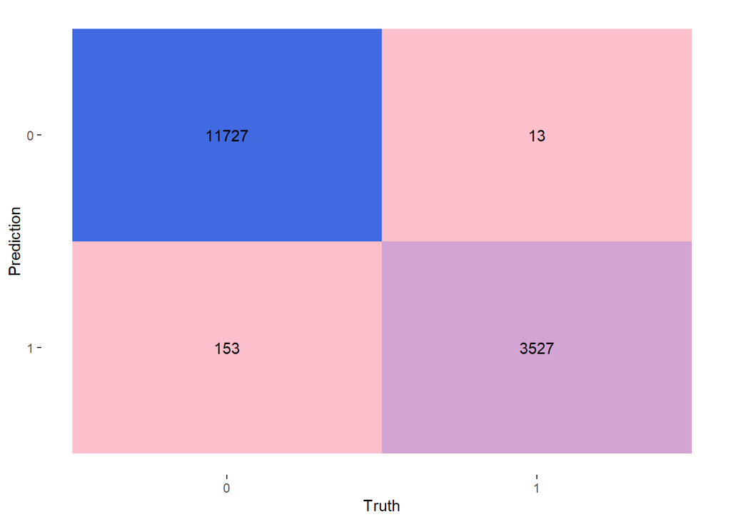

The `xgboost` model was fitted to the training set:

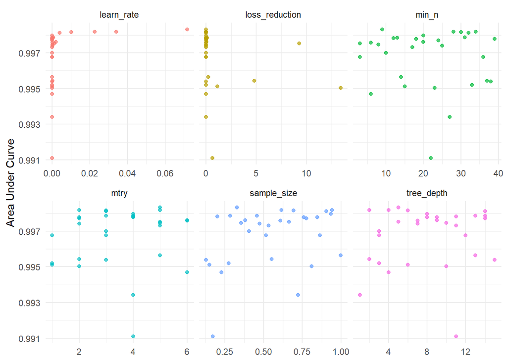

The model performance improved upon the svm model. `Light` is determined to be the most impactful predictor.

```
## # A tibble: 5 x 12
##    mtry min_n tree_depth learn_rate loss_reduction sample_size .metric
##   <int> <int>      <int>      <dbl>          <dbl>       <dbl> <chr>
## 1     5     9          5  0.0717          9.55e-10       0.327 accuracy
## 2     5    28          4  0.0340          1.09e- 2       0.614 accuracy
## 3     2    34          2  0.0226          1.09e- 3       0.943 accuracy
## 4     6     6          7  0.0000149       3.92e- 3       0.608 accuracy
## 5     3    30          6  0.0102          1.14e- 4       0.693 accuracy
## # ... with 5 more variables: .estimator <chr>, mean <dbl>, n <int>,
## #   std_err <dbl>, .config <chr>
```

```
## [21:31:55] WARNING: amalgamation/../src/learner.cc:1115: Starting in XGBoost 1.3.0, the default evaluation metric used with the objective 'binary:logistic' was changed from 'error' to 'logloss'. Explicitly set eval_metric if you'd like to restore the old behavior.
```

```
## [21:32:03] WARNING: amalgamation/../src/learner.cc:1115: Starting in XGBoost 1.3.0, the default evaluation metric used with the objective 'binary:logistic' was changed from 'error' to 'logloss'. Explicitly set eval_metric if you'd like to restore the old behavior.
```

```
## == Workflow ====================================================================
## Preprocessor: Recipe
## Model: boost_tree()
##
## -- Preprocessor ----------------------------------------------------------------
## 0 Recipe Steps
##
## -- Model -----------------------------------------------------------------------
## Boosted Tree Model Specification (classification)
##
## Main Arguments:
##   mtry = 5
##   trees = 1000
##   min_n = 9
##   tree_depth = 5
##   learn_rate = 0.0716715895750092
##   loss_reduction = 9.54857586140021e-10
##   sample_size = 0.327152691166848
##
## Computational engine: xgboost
```

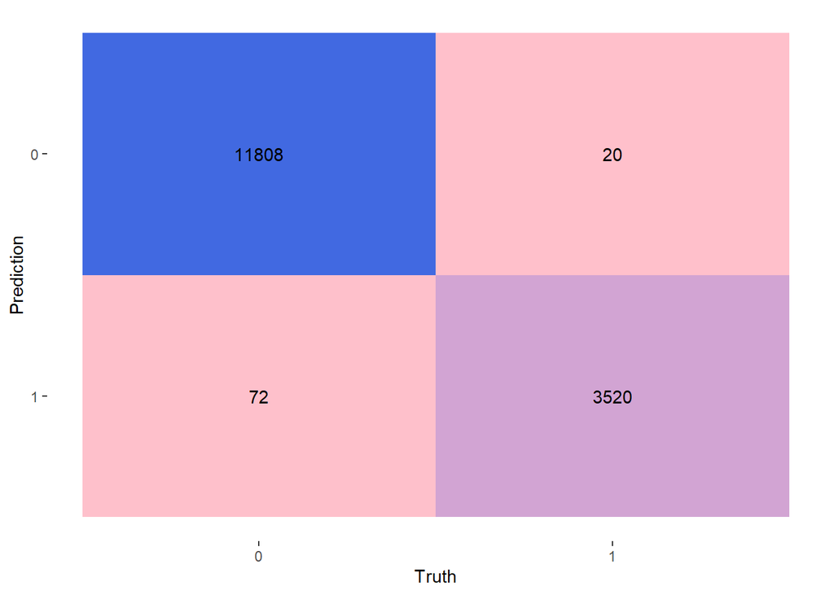

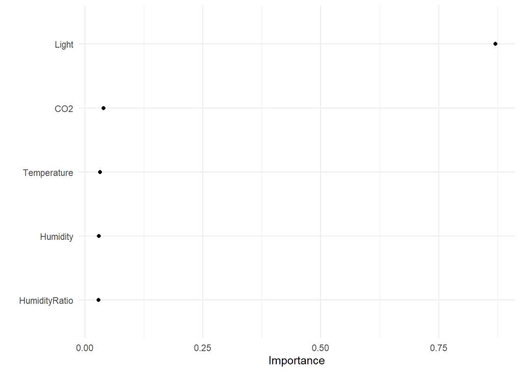

Lastly, the best `xgboost` model was fitted to the testing data, resulting in 99.1% prediction accuracy:

```
## # A tibble: 2 x 4
##   .metric  .estimator .estimate .config
##   <chr>    <chr>          <dbl> <chr>
## 1 accuracy binary         0.991 Preprocessor1_Model1
## 2 roc_auc  binary         0.997 Preprocessor1_Model1
```

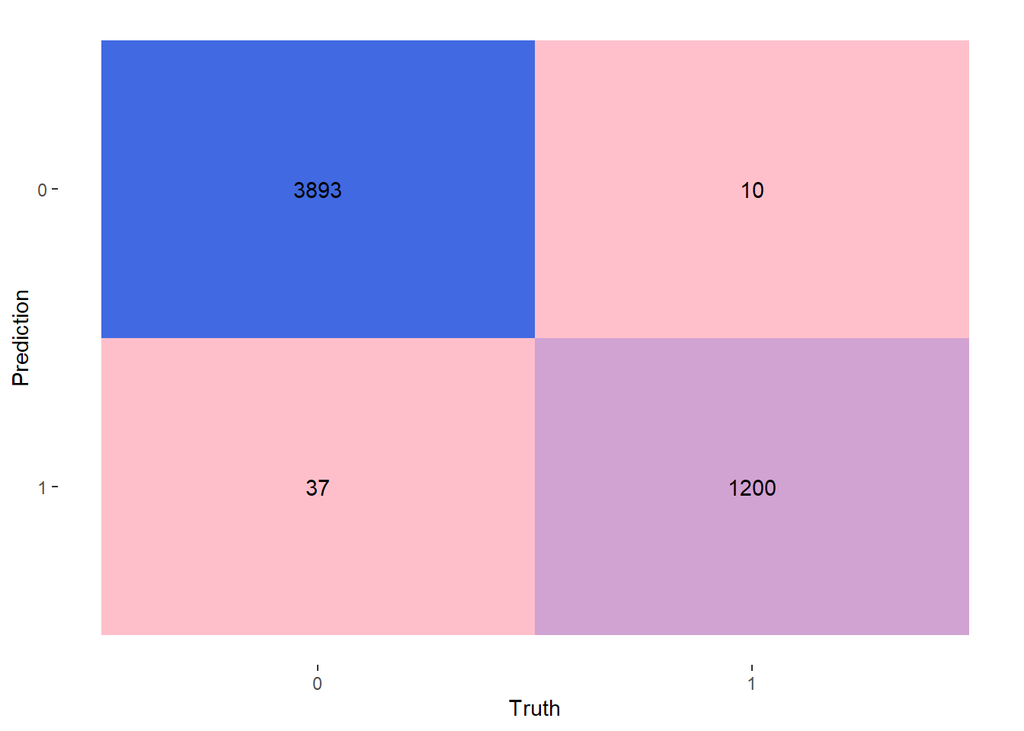

#### **Reflection**

The `svm` and `xgboost` models performed well on the given dataset with an estimated error rate under 3%. Testing the models on a larger, scalable data set would be beneficial in attempting to further optimize the model, although the results would likely hold. There are several possibilities for next steps and future research. An important consideration is the application of the room sensors and their sensitivity requirement. Further research could explore the minimum and/or maximum values that trigger detection and determine the threshold of what classifies as a person, as opposed to a child or large animal. `Light` was the most important factor, so it may be worth looking into how the sensors perform in the absence of light. Alternatively, would the models perform the same with *only* the light variable. Due to time constraints, neural networks and deep learning classification methods were not used.

#### **References**

- Edwin K. P. Chong, Stanislaw H. Zak (2013). An Introduction to Optimization (4th Ed.). John Wiley & Sons https://books.google.com/books/about/An_Introduction_to_Optimization.html?id=8J_ev5ihKEoC
- Chen T., Guestrin, C. (2016). XGBoost: A Scalable Tree Boosting System. DOI https://dl.acm.org/doi/10.1145/2939672.2939785

#### **Appendix**

```r
knitr::opts_chunk$set(echo = FALSE,
                      include = FALSE,
                      fig.show = "hold",
                      out.width = "50%",
                      message = F)
library(tidyverse)
library(tidymodels)
library(doParallel)
library(vip)
occupancy <- read.csv("../data/occupancy_data.csv") %>%
  mutate(Occupancy = as_factor(Occupancy))
occupancy %>%
  count(Occupancy)

occupancy %>%
  select(where(is.numeric)) %>%
  cor(use = 'complete.obs', method = "pearson")
skimr::skim(occupancy)
occupancy %>%
  ggplot(aes(x = Temperature, color = Occupancy))+
  geom_freqpoly(binwidth = 0.2)+
  theme_minimal()

occupancy %>%
  ggplot(aes(x = CO2, color = Occupancy))+
  geom_freqpoly(binwidth = 10)+
  theme_minimal()

occupancy %>%
  ggplot(aes(x = Light, color = Occupancy))+
  geom_freqpoly(binwidth = 10)+
  theme_minimal()

occupancy %>%
  ggplot(aes(x = Humidity, color = Occupancy))+
  geom_freqpoly(binwidth = 0.2)+
  theme_minimal()
set.seed(123)

occ <- occupancy %>%
  select(-date)

occ_split <- initial_split(occ)
occ_train <- training(occ_split)
occ_test <- testing(occ_split)

occ_folds <- vfold_cv(occ_train, v = 10, strata = Occupancy)
log_rec <- recipe(Occupancy ~ ., data = occ_train)

occ_log <- occ_train %>%
  mutate(log_temp = log(Temperature+1),
         log_humid = log(Humidity+1),
         log_light = log(Light+1),
         log_co2 = log(CO2+1))
log_fit <- glm(Occupancy ~ Temperature + Humidity + Light + CO2 +
                 Temperature:log_temp + Humidity:log_humid +
                 Light:log_light + CO2:log_co2,
               family = binomial(link = 'logit'), data = occ_log)

summary(log_fit)
svm_rec <- recipe(Occupancy ~ ., data = occ_train) %>%
  step_normalize(all_numeric_predictors())

svm_lin_spec <- svm_linear() %>%
  set_mode("classification") %>%
  set_engine("kernlab")
svm_wf <- workflow(svm_rec, svm_lin_spec)
svm_fit <- fit(svm_wf, data = occ_train)

svm_fit %>%
  augment(new_data = occ_train) %>%
  conf_mat(Occupancy, .pred_class) %>%
  autoplot(type = "heatmap") +
  scale_fill_gradient(low = 'pink', high = 'royalblue')

augment(svm_fit, occ_train) %>%
  accuracy(truth = Occupancy, estimate = .pred_class)


xgb_rec <- recipe(Occupancy ~ ., data = occ_train)
require(xgboost)
xgb_spec <- boost_tree(
  trees = 1000,
  tree_depth = tune(),
  min_n = tune(),
  loss_reduction = tune(),
  sample_size = tune(),
  mtry = tune(),
  learn_rate = tune()
) %>%
  set_engine('xgboost') %>%
  set_mode('classification')

xgb_spec
xgb_grid <- grid_latin_hypercube(
  tree_depth(),
  min_n(),
  loss_reduction(),
  sample_size = sample_prop(),
  finalize(mtry(), occ_train),
  learn_rate(),
  size = 30
)

xgb_wflow <- workflow() %>%
  add_recipe(xgb_rec) %>%
  add_model(xgb_spec)

xgb_wflow
cl_mergen <- makePSOCKcluster(detectCores())
registerDoParallel(cl_mergen)

set.seed(200)
xgb_fit <- tune_grid(
  xgb_wflow,
  resamples = occ_folds,
  grid = xgb_grid,
  control = control_grid(save_pred = TRUE)
)
xgb_fit %>%
  collect_metrics() %>%
  filter(.metric == 'roc_auc') %>%
  select(mean, mtry:sample_size) %>%
  pivot_longer(mtry:sample_size,
               values_to = 'value',
               names_to = 'parameter') %>%
  ggplot(aes(x = value, y = mean, color = parameter)) +
  geom_point(alpha = 0.7, show.legend = FALSE)+
  facet_wrap(~parameter, scales = 'free_x') +
  labs(x = NULL, y = 'Area Under Curve')+
  theme_minimal()
xgb_fit %>%
  show_best(metric = 'accuracy')

xgb_best <- xgb_fit %>%
  select_best('accuracy')

xgb_final <- finalize_workflow(xgb_wflow, xgb_best)

xgb_final %>%
  fit(data = occ_train) %>%
  augment(new_data = occ_train) %>%
  conf_mat(truth = Occupancy, estimate = .pred_class) %>%
  autoplot('heatmap') +
  scale_fill_gradient(low = 'pink', high = 'royalblue')

xgb_final %>%
  fit(data = occ_train) %>%
  extract_fit_parsnip() %>%
  vip(geom = 'point')+
  theme_minimal()

xgb_final
xgb_final_test <- last_fit(xgb_final, occ_split)
collect_metrics(xgb_final_test)


xgb_final_test$.predictions[[1]] %>%
  conf_mat(Occupancy, .pred_class) %>%
  autoplot('heatmap')+
  scale_fill_gradient(low = 'pink', high = 'royalblue')
```